# Assignment_3_Problem_1

##### 5. (3pt) The variable native-country is sparse, meaning it has too many levels, where some levels occur infrequently. Most machine learning algorithms do not work well with spares data. One-hot-encoding or dummy coding of these variables will increase feature dimensions significantly and typically some preprocessing is required to reduce the number of levels. One approach is to group together the levels which occur infrequently. For instance, one could combine together countries with less than 0.1% occurrence in the data to an “other” category. Another possibility is to use domain knowledge; for instance, combine countries based on their geographic location ( “Middle East”, “East-Europe”, “West-Europe”, etc. In a subsequent assignment we will use “feature hashing” which is yet another way to deal with sparse data but for now, please read the section on Making use of sparse data (remapping sparse categorical data) in chapter 13 of the textbook Machine learning with R. Then combine some of the infrequent levels of the native-country. You can decide whether you want to combine the levels based on frequency or domain knowledge. Either one is fine for this assignment but preference will be with a choice that would increase the cross validation performance of the ML models you will train subsequently.

```r
# creating regions list
countries_categories <- list(
  "east asia" = c(" Taiwan", " China", " Japan", " Hong"),
  "south asia" = c(" India"),
  "south east asia" = c(" Philippines" , " Cambodia", " Thailand", " Laos", " Vietnam" ),
  "middle east" = c(" Iran"),
  "east europe" = c(" Poland", " Yugoslavia", " Hungary"),
  "west eurpoe" = c(" England", " Germany", " Italy", " Portugal", " France", " Scotland", " Greece", " Ireland", " Holand-Netherlands"),
  "north america and territories" = c(" United-States"," Puerto-Rico" ," Canada", " Outlying-US(Guam-USVI-etc)" ),
  "south america" = c(),
  "latin america" = c(" Cuba"," Jamaica"," Mexico"," Honduras"," Columbia", " Ecuador" , " Haiti", " Dominican-Republic" ,
                      " El-Salvador", " Guatemala", " Peru" , " Trinadad&Tobago", " Nicaragua"),
  "east africa" = c(),
  "west africa" = c(),
  "north africa" = c(),
  "south africa" = c(),
  "oceania" = c(" South")
)

# Creating a unction to map countries to theri regiojs
get_region_fn <- function(country) {
  for (region_name in names(countries_categories)) {
    if (country %in% countries_categories[[region_name]]) {
      return(region_name)
    }
  }
  return("Other")
}
```

```r
# let us update the data values in the feature
adult_data_train$native_country <- sapply(adult_data_train$native_country, get_region_fn)

# also in test data
adult_data_test$native_country <- sapply(adult_data_test$native_country, get_region_fn)

## --test--
print(unique(adult_data_train$native_country))
```

```
## [1] "north america and territories" "latin america"
## [3] "south east asia"               "east europe"
## [5] "east asia"                     "west eurpoe"
## [7] "south asia"                    "middle east"
## [9] "oceania"
```

##### 6. (3pt) Use appropriate plots and statistic tests to find which variables in the dataset are associated with “income”. Remove the variable(s) that are not associated with income.

For this I have to check the str and make necessary data type chnges. For this I am gonna reuse the codes from my previous assignments.

```r
# ---test---
str(adult_data_train)
```

```
## 'data.frame':    26049 obs. of  15 variables:
##  $ age           : int  33 26 40 36 43 23 34 34 38 37 ...
##  $ workclass     : chr  "Unknown" " Private" " Private" " Self-emp-inc" ...
##  $ fnlwgt        : int  102130 130931 233130 107218 28451 161708 62463 254304 348739 114605 ...
##  $ education     : chr  " Some-college" " HS-grad" " 7th-8th" " Some-college" ...
##  $ education_num : int  10 9 4 10 13 13 10 9 15 9 ...
##  $ marital_status: chr  " Never-married" " Never-married" " Married-civ-spouse" " Divorced" ...
##  $ occupation    : chr  "Unknown" " Adm-clerical" " Craft-repair" " Sales" ...
##  $ relationship  : chr  " Own-child" " Own-child" " Husband" " Unmarried" ...
##  $ race          : chr  " White" " Black" " White" " Asian-Pac-Islander" ...
##  $ sex           : chr  " Male" " Female" " Male" " Male" ...
##  $ capital_gain  : int  0 0 0 0 0 0 0 4508 0 0 ...
##  $ capital_loss  : int  0 0 0 0 0 0 1579 0 0 0 ...
##  $ hours_per_week: int  40 40 40 55 37 30 40 90 60 40 ...
##  $ native_country: chr  "north america and territories" "north america and territories" "latin america" "north america and territories" ...
##  $ income        : chr  " <=50K" " <=50K" " <=50K" " <=50K" ...
```

```r
str(adult_data_test)
```

```
## 'data.frame':    6512 obs. of  15 variables:
##  $ age           : int  30 32 59 30 22 48 47 30 29 25 ...
##  $ workclass     : chr  " State-gov" " Private" " Private" " Federal-gov" ...
##  $ fnlwgt        : int  141297 205019 109015 59951 311512 265477 51835 59496 105598 200681 ...
##  $ education     : chr  " Bachelors" " Assoc-acdm" " HS-grad" " Some-college" ...
##  $ education_num : int  13 12 9 10 10 12 15 13 10 10 ...
##  $ marital_status: chr  " Married-civ-spouse" " Never-married" " Divorced" " Married-civ-spouse" ...
##  $ occupation    : chr  " Prof-specialty" " Sales" " Tech-support" " Adm-clerical" ...
##  $ relationship  : chr  " Husband" " Not-in-family" " Unmarried" " Own-child" ...
##  $ race          : chr  " Asian-Pac-Islander" " Black" " White" " White" ...
##  $ sex           : chr  " Male" " Male" " Female" " Male" ...
##  $ capital_gain  : int  0 0 0 0 0 0 0 2407 0 0 ...
##  $ capital_loss  : int  0 0 0 0 0 0 1902 0 0 0 ...
##  $ hours_per_week: int  40 50 40 40 15 40 60 40 58 40 ...
##  $ native_country: chr  "south asia" "north america and territories" "north america and territories" "north america and territories" ...
##  $ income        : chr  " >50K" " <=50K" " <=50K" " <=50K" ...
```

```r
# Code resued from my Assignemnetn 2 solution
numeric_cols <- colnames(adult_data_train)[sapply(adult_data_train, is.numeric)]
factor_cols <- colnames(adult_data_train)[sapply(adult_data_train, is.factor)]
character_cols <- colnames(adult_data_train)[sapply(adult_data_train, is.character)]

# Checking the column names
cat("Numeric columns: \n------\n", paste(numeric_cols, collapse = ", "), "\n")
```

```
## Numeric columns:
## ------
##  age, fnlwgt, education_num, capital_gain, capital_loss, hours_per_week
```

```r
cat("Factor columns: \n------\n", paste(factor_cols, collapse = ", "), "\n")
```

```
## Factor columns:
## ------
##
```

```r
cat("Character columns: \n------\n", paste(character_cols, collapse = ", "), "\n")
```

```
## Character columns:
## ------
##  workclass, education, marital_status, occupation, relationship, race, sex, native_country, income
```

Let us make them all nominal factor variables.

```r
# Let us make them factor variables in both train and test data sets
for(cc in character_cols) {
  adult_data_train[, cc] <- factor(adult_data_train[, cc])
  adult_data_test[, cc] <- factor(adult_data_test[, cc])
}
```

```r
# Code resued from my Assignemnetn 2 solution
numeric_cols <- colnames(adult_data_train)[sapply(adult_data_train, is.numeric)]
factor_cols <- colnames(adult_data_train)[sapply(adult_data_train, is.factor)]
character_cols <- colnames(adult_data_train)[sapply(adult_data_train, is.character)]

# Checking the column names
cat("Numeric columns: \n------\n", paste(numeric_cols, collapse = ", "), "\n")
```

```
## Numeric columns:
## ------
##  age, fnlwgt, education_num, capital_gain, capital_loss, hours_per_week
```

```r
cat("Factor columns: \n------\n", paste(factor_cols, collapse = ", "), "\n")
```

```
## Factor columns:
## ------
##  workclass, education, marital_status, occupation, relationship, race, sex, native_country, income
```

```r
cat("Character columns: \n------\n", paste(character_cols, collapse = ", "), "\n")
```

```
## Character columns:
## ------
##
```

```
## [1] "*************age*************"
```

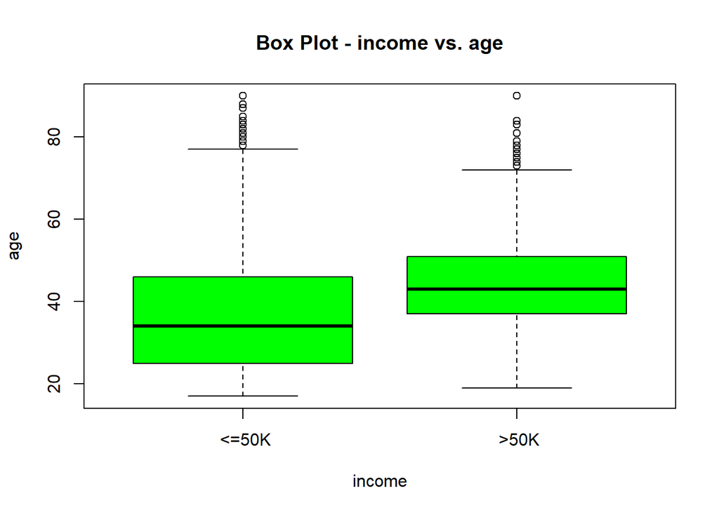

```
##
##  Welch Two Sample t-test
##
## data:  df[, v] by df[, target_var]
## t = -44.779, df = 13798, p-value < 2.2e-16
## alternative hypothesis: true difference in means between group  <=50K and group  >50K is not equal to 0
## 95 percent confidence interval:
##  -7.766657 -7.115217
## sample estimates:
## mean in group  <=50K  mean in group  >50K
##             36.80541             44.24634
##
## [1] "*************fnlwgt*************"
```

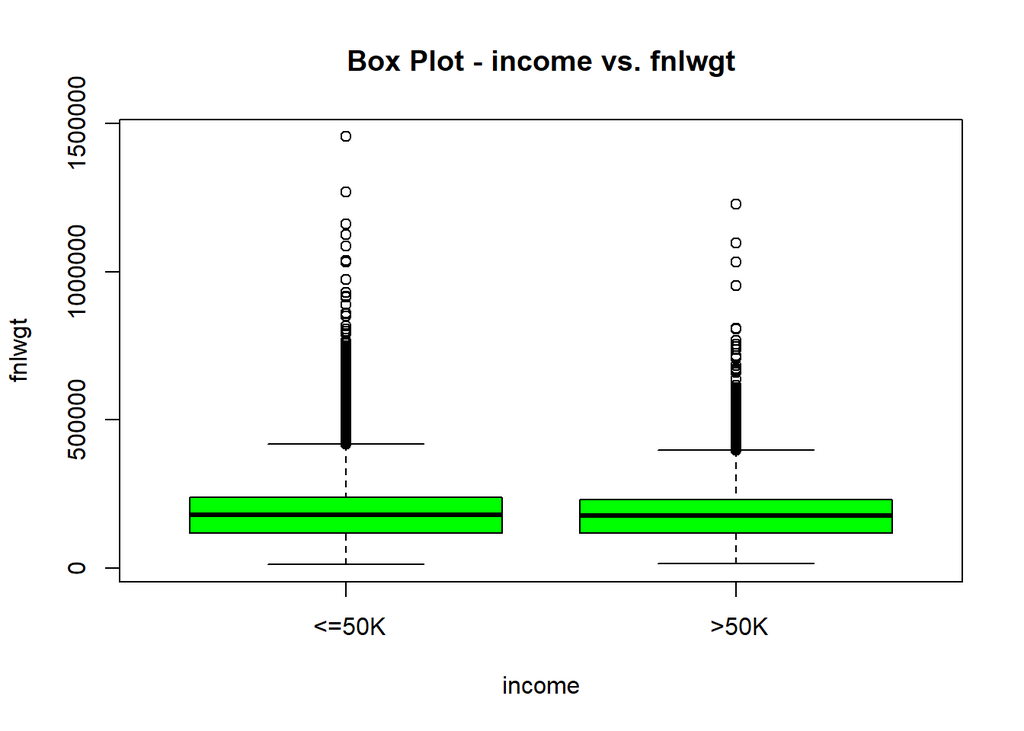

```
##
##  Welch Two Sample t-test
##
## data:  df[, v] by df[, target_var]
## t = 1.2322, df = 10617, p-value = 0.2179
## alternative hypothesis: true difference in means between group  <=50K and group  >50K is not equal to 0
## 95 percent confidence interval:
##  -1103.947  4840.712
## sample estimates:
## mean in group  <=50K  mean in group  >50K
##             190129.1             188260.7
##
## [1] "*************education_num*************"
```

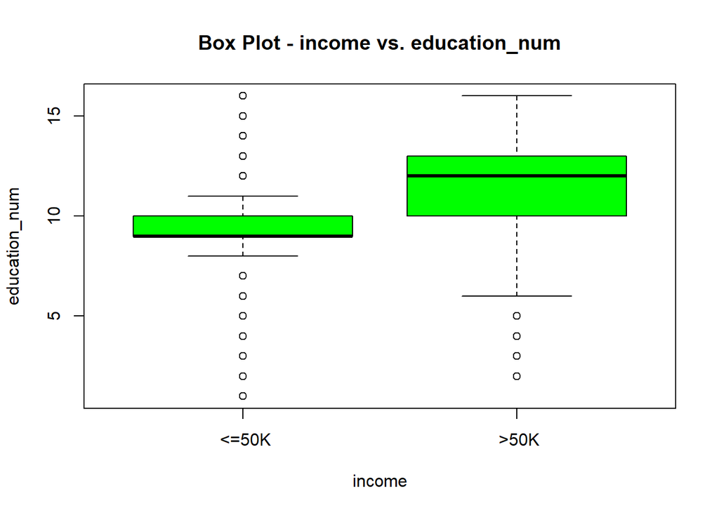

```
##
##  Welch Two Sample t-test
##
## data:  df[, v] by df[, target_var]
## t = -57.734, df = 10582, p-value < 2.2e-16
## alternative hypothesis: true difference in means between group  <=50K and group  >50K is not equal to 0
## 95 percent confidence interval:
##  -2.079213 -1.942663
## sample estimates:
## mean in group  <=50K  mean in group  >50K
##             9.595682            11.606621
##
## [1] "*************capital_gain*************"
```

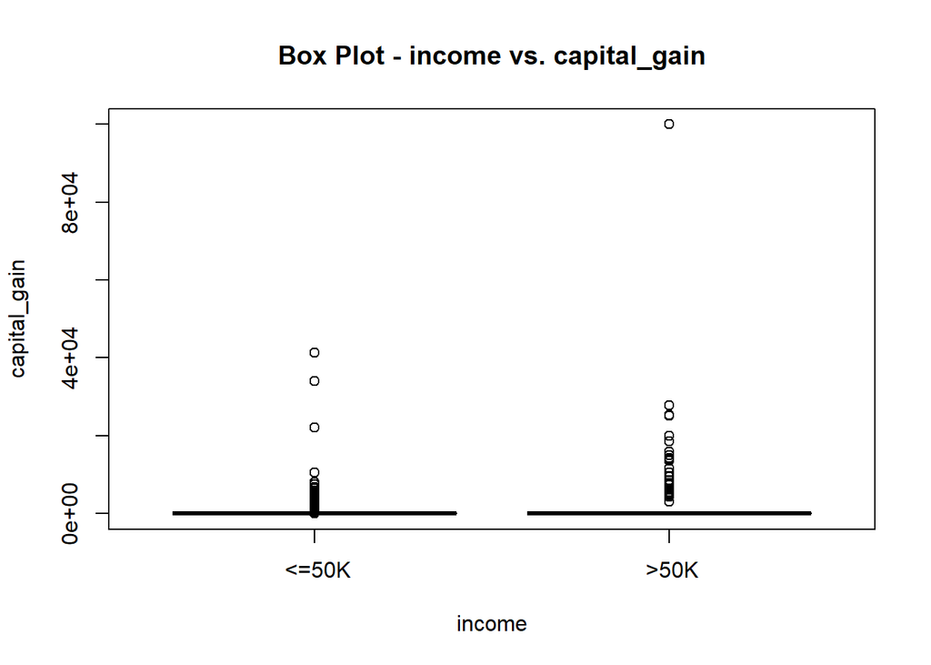

```
##
##  Welch Two Sample t-test
##
## data:  df[, v] by df[, target_var]
## t = -20.818, df = 6237.3, p-value < 2.2e-16
## alternative hypothesis: true difference in means between group  <=50K and group  >50K is not equal to 0
## 95 percent confidence interval:
##  -4305.170 -3564.146
## sample estimates:
## mean in group  <=50K  mean in group  >50K
##             146.9062            4081.5642
##
## [1] "*************capital_loss*************"
```

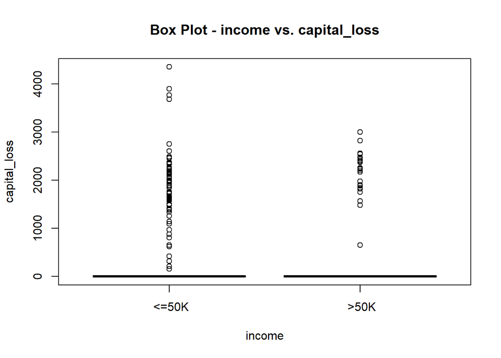

```
##
##  Welch Two Sample t-test
##
## data:  df[, v] by df[, target_var]
## t = -17.226, df = 7365.3, p-value < 2.2e-16
## alternative hypothesis: true difference in means between group  <=50K and group  >50K is not equal to 0
## 95 percent confidence interval:
##  -148.1840 -117.9039
## sample estimates:
## mean in group  <=50K  mean in group  >50K
##             53.53712            186.58107
##
## [1] "*************hours_per_week*************"
```

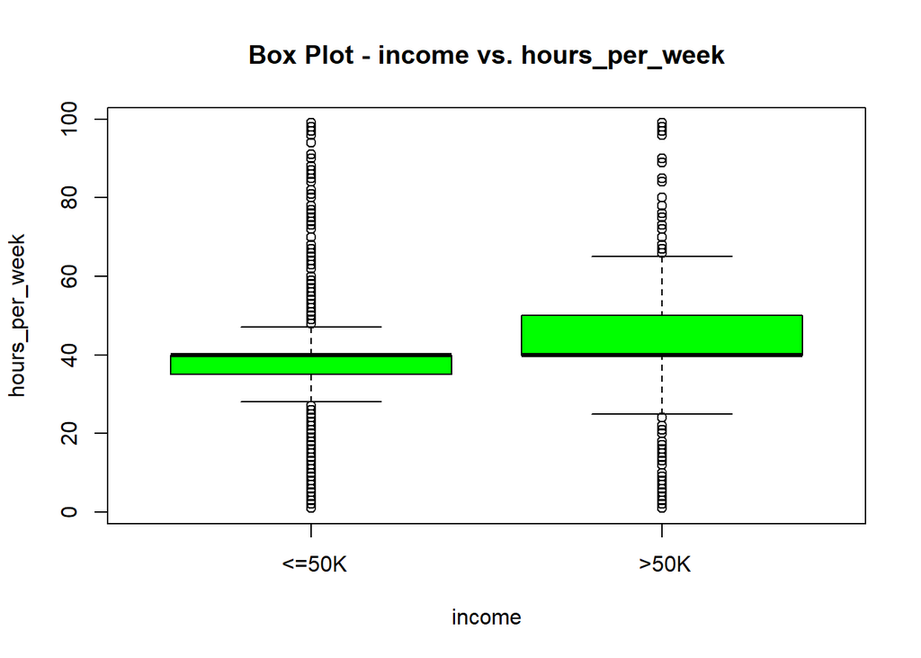

```
##
##  Welch Two Sample t-test
##
## data:  df[, v] by df[, target_var]
## t = -40.56, df = 11472, p-value < 2.2e-16
## alternative hypothesis: true difference in means between group  <=50K and group  >50K is not equal to 0
## 95 percent confidence interval:
##  -6.998332 -6.353086
## sample estimates:
## mean in group  <=50K  mean in group  >50K
##             38.81746             45.49317
```

```r
# Once again reusing code from the previous assignements

## Reused My Code from the Assignment 1 - automation
## and made it into a function

# Nuerical vs Categ(2 types) - Two test
diagnose_association_numerical <- function(df,
                                           numer_vars,
                                           target_var,
                                           signif_val = 0.05) {
  numer_p_value_dataframe <- data.frame()
  for(v in numer_vars){

    print(paste("*************",v,"*************",sep= ""))
    plot(df[,v]~df[, target_var],
       col="green",
       main = paste("Box Plot - ",target_var," vs. ",v, sep = ""),
       xlab = target_var,
       ylab = v)

    # t.test - to test whether a categorical variable with two levels is
    # independent of a continuous numerical variable
    numer_Test_details = t.test(df[,v] ~ df[,target_var],
                                alternative = "two.sided")
    print(numer_Test_details)
    numer_p_value_dataframe <- rbind(
      numer_p_value_dataframe,
      data.frame(feature1 = target_var,
                 feature2 = v,
                 p.value = numer_Test_details["p.value"],
                 test_name = "ttest"))
    }

  numer_p_value_dataframe$signif <- signif_val
  numer_p_value_dataframe$result <- (
    ifelse(
      numer_p_value_dataframe$p.value < numer_p_value_dataframe$signif,
      "pass", "fail" ))

  return(numer_p_value_dataframe)

}

# Categorical vs Categoricl - ChiSQ Test
diagnose_association_factor <- function(df,
                                        factor_vars,
                                        target_var,
                                        signif_val = 0.05) {

  factor_p_value_dataframe <- data.frame()
  for(v in factor_vars[(!factor_vars %in% c(target_var))]){
    print(paste("--------------------",v,"--------------------"))
    ctable <- table(df[, v], df[, target_var])
    mosaicplot(ctable,
               ylab = target_var,
               xlab = v,
               main = paste("Mosaic graph of",target_var,"vs",v,sep = " "))
    print(chisq.test(ctable))
    factor_Test_details = chisq.test(ctable)
    factor_p_value_dataframe <- rbind(
      factor_p_value_dataframe,
      data.frame(feature1 = target_var,
                 feature2 = v,
                 p.value = factor_Test_details["p.value"],
                 test_name = "chisq"))
    }

  factor_p_value_dataframe$signif <- signif_val
  factor_p_value_dataframe$result <- (
    ifelse(
      factor_p_value_dataframe$p.value < factor_p_value_dataframe$signif,
      "pass", "fail" ))

  return(factor_p_value_dataframe)
}

target_DV = "income"

assoc_num_df <- diagnose_association_numerical(df = adult_data_train,
                                               numer_vars = numeric_cols,
                                               target_var = target_DV)
```

```r
assoc_fac_df <- diagnose_association_factor(df = adult_data_train,
                                            factor_vars = factor_cols,
                                            target_var = target_DV)
```

```
## [1] "-------------------- workclass --------------------"
```

[output not shown]

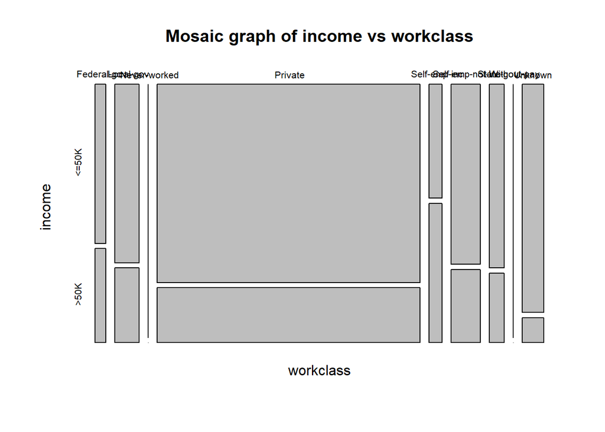

```
## [1] "-------------------- education --------------------"
```

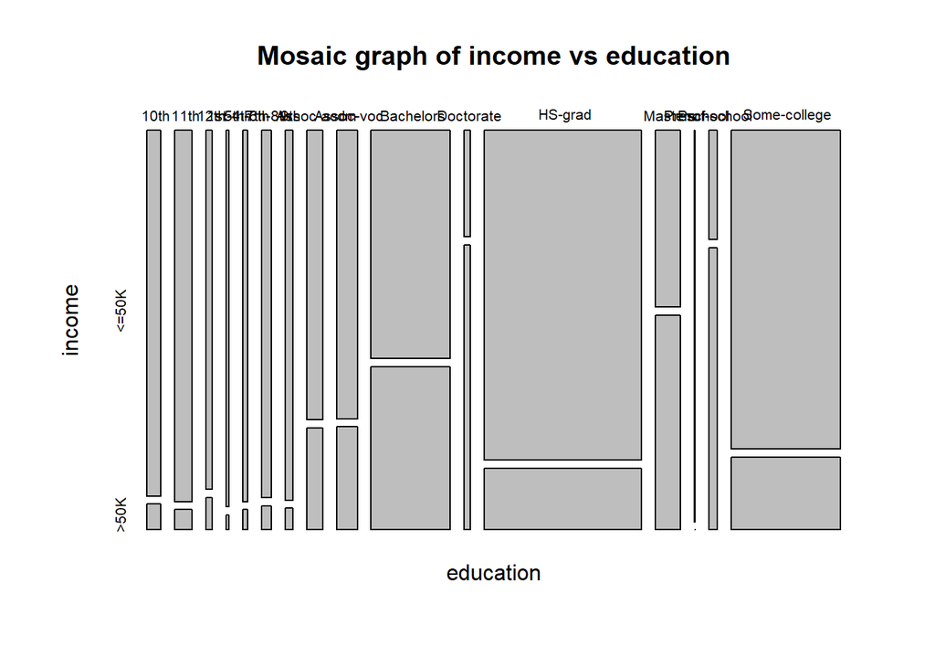

```
##
##  Pearson's Chi-squared test
##
## data:  ctable
## X-squared = 3500.8, df = 15, p-value < 2.2e-16
##
## [1] "-------------------- marital_status --------------------"
```

[output not shown]

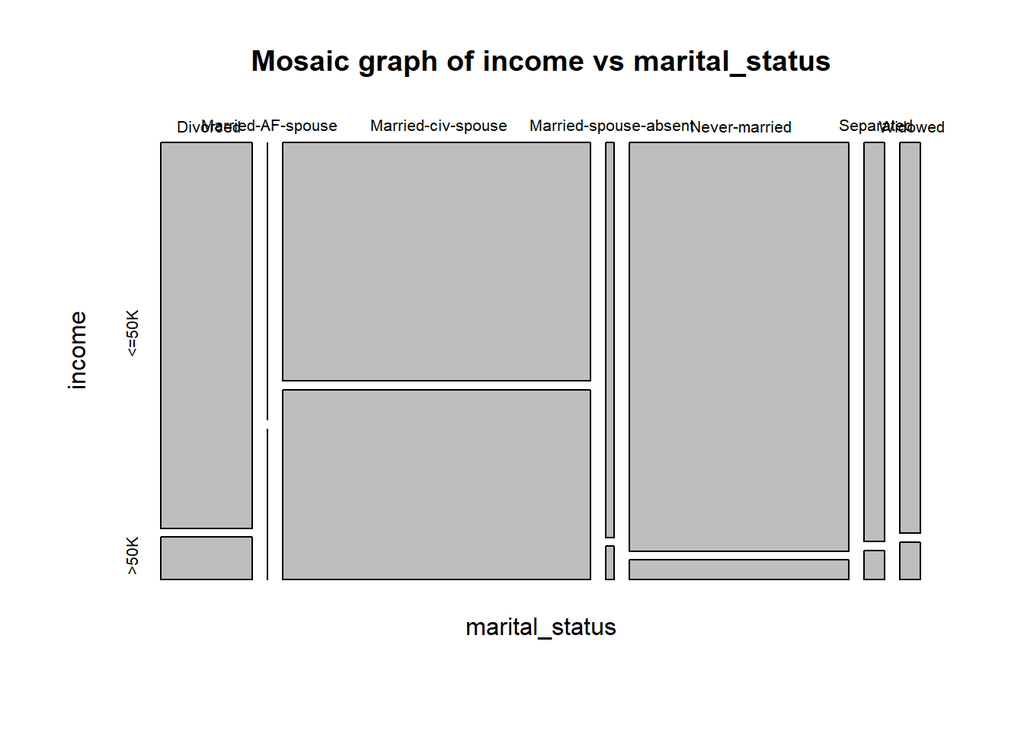

```
## [1] "-------------------- occupation --------------------"
```

[output not shown]

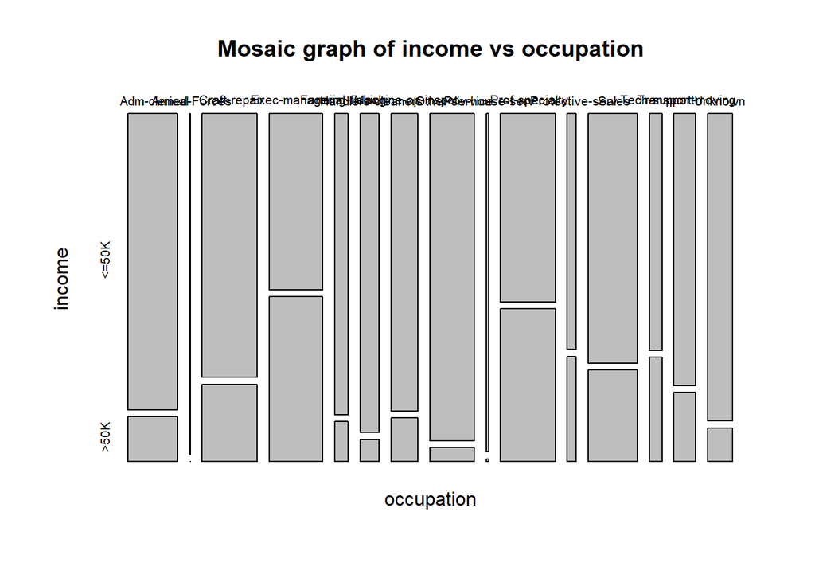

```
## [1] "-------------------- relationship --------------------"
```

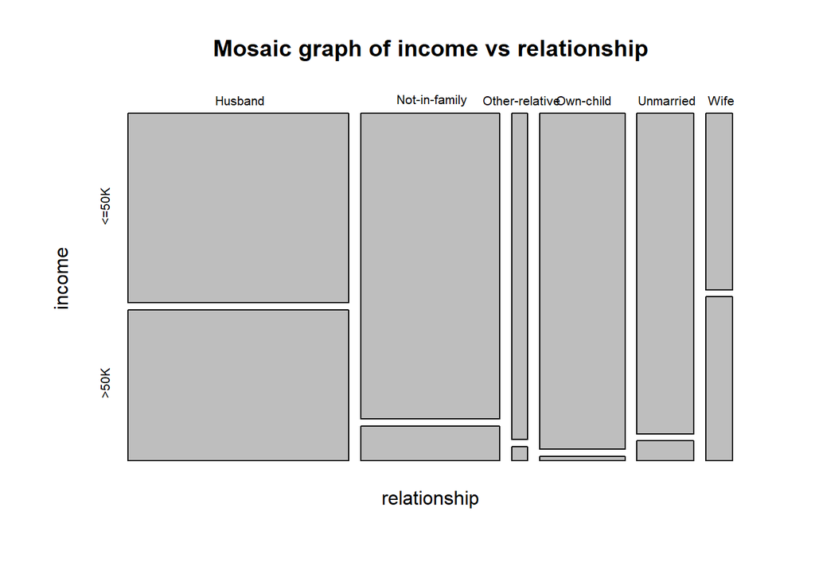

```
##
##  Pearson's Chi-squared test
##
## data:  ctable
## X-squared = 5316.4, df = 5, p-value < 2.2e-16
##
## [1] "-------------------- race --------------------"
```

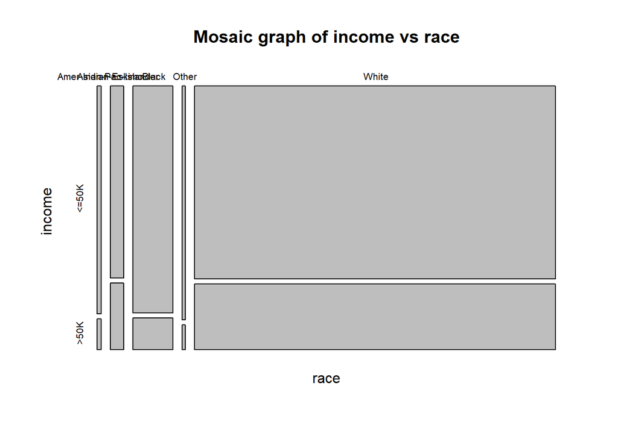

```
##
##  Pearson's Chi-squared test
##
## data:  ctable
## X-squared = 257.67, df = 4, p-value < 2.2e-16
##
## [1] "-------------------- sex --------------------"
```

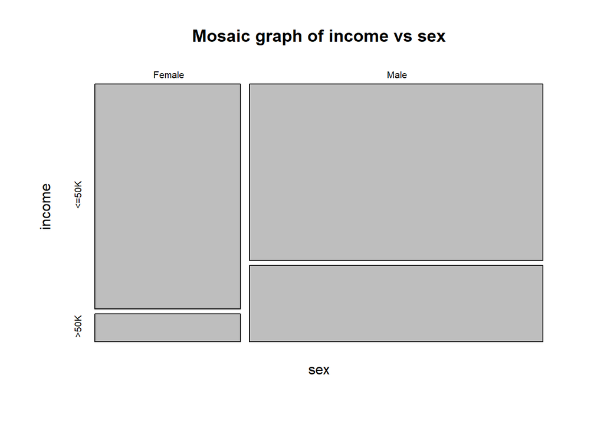

```
##
##  Pearson's Chi-squared test with Yates' continuity correction
##
## data:  ctable
## X-squared = 1170.6, df = 1, p-value < 2.2e-16
##
## [1] "-------------------- native_country --------------------"
```

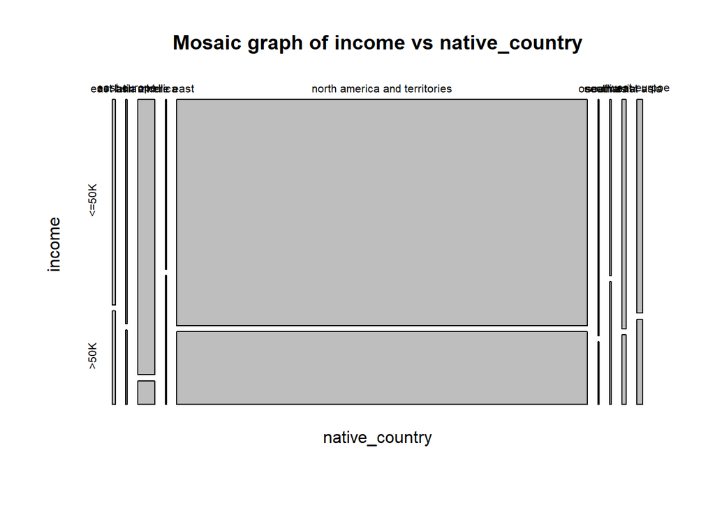

```
##
##  Pearson's Chi-squared test
##
## data:  ctable
## X-squared = 176.3, df = 8, p-value < 2.2e-16
```

```r
qualified_features_data <- assoc_num_df %>% rbind.data.frame(assoc_fac_df)

qualified_features_data
```

```
##    feature1       feature2       p.value test_name signif result
## 1    income            age  0.000000e+00     ttest   0.05   pass
## 2    income         fnlwgt  2.179172e-01     ttest   0.05   fail
## 3    income  education_num  0.000000e+00     ttest   0.05   pass
## 4    income   capital_gain  4.113356e-93     ttest   0.05   pass
## 5    income   capital_loss  3.170872e-65     ttest   0.05   pass
## 6    income hours_per_week  0.000000e+00     ttest   0.05   pass
## 7    income      workclass 1.810436e-172     chisq   0.05   pass
## 8    income      education  0.000000e+00     chisq   0.05   pass
## 9    income marital_status  0.000000e+00     chisq   0.05   pass
## 10   income     occupation  0.000000e+00     chisq   0.05   pass
## 11   income   relationship  0.000000e+00     chisq   0.05   pass
## 12   income           race  1.445786e-54     chisq   0.05   pass
## 13   income            sex 1.469375e-256     chisq   0.05   pass
## 14   income native_country  6.152309e-34     chisq   0.05   pass
```

```r
# Removing the variable from the
unqualified_feature <- qualified_features_data[(qualified_features_data$result == "fail"), "feature2"]

# Discarding that feature
adult_data_train <- adult_data_train %>% select(-one_of(unqualified_feature))
adult_data_test <- adult_data_test %>% select(-one_of(unqualified_feature))
```

##### 7. (2pt) Train a logistic regression model on the train data (preprocessed and transformed using above steps) using the glm package and use it to predict “income” for the test data. Note: As explained in the lectures, “predict” method will return predicted probabilities. To convert them to labels, you need to use some threshold ( typically set as 50%) and if the predicted probability is greater than 50% you predict income>50K; otherwise predict income<=50K ( please review the example in lecture 7.2).

```r
# Training the model
log_reg_model <- glm(income~., data = adult_data_train, family = "binomial")
summary(log_reg_model)
```

```
##
## Call:
## glm(formula = income ~ ., family = "binomial", data = adult_data_train)
##
## Deviance Residuals:
##     Min       1Q   Median       3Q      Max
## -5.0521  -0.5103  -0.1848  -0.0306   3.3921
##
## Coefficients: (2 not defined because of singularities)
##                                               Estimate Std. Error z value
## (Intercept)                                 -7.826e+00  5.483e-01 -14.272
## age                                          2.641e-02  1.841e-03  14.348
## workclass Local-gov                         -5.873e-01  1.261e-01  -4.656
## workclass Never-worked                      -1.223e+01  3.666e+02  -0.033
## workclass Private                           -4.270e-01  1.051e-01  -4.061
## workclass Self-emp-inc                      -2.842e-01  1.373e-01  -2.070
## workclass Self-emp-not-inc                  -9.154e-01  1.227e-01  -7.461
## workclass State-gov                         -6.940e-01  1.396e-01  -4.973
## workclass Without-pay                       -1.317e+01  2.207e+02  -0.060
## workclassUnknown                            -1.196e+00  1.584e-01  -7.553
## education 11th                               1.750e-01  2.354e-01   0.743
## education 12th                               5.853e-01  2.923e-01   2.003
## education 1st-4th                           -4.165e-01  5.346e-01  -0.779
## education 5th-6th                           -1.603e-01  3.479e-01  -0.461
## education 7th-8th                           -5.580e-01  2.621e-01  -2.129
## education 9th                               -2.091e-01  2.876e-01  -0.727
## education Assoc-acdm                         1.488e+00  1.965e-01   7.572
## education Assoc-voc                          1.371e+00  1.897e-01   7.231
## education Bachelors                          1.959e+00  1.768e-01  11.080
## education Doctorate                          2.963e+00  2.379e-01  12.456
## education HS-grad                            8.355e-01  1.724e-01   4.846
## education Masters                            2.277e+00  1.886e-01  12.075
## education Preschool                         -1.081e+01  1.238e+02  -0.087
## education Prof-school                        2.807e+00  2.219e-01  12.646
## education Some-college                       1.167e+00  1.748e-01   6.675
## education_num                                       NA         NA      NA
## marital_status Married-AF-spouse             2.116e+00  6.597e-01   3.207
## marital_status Married-civ-spouse            2.131e+00  2.969e-01   7.180
## marital_status Married-spouse-absent         7.487e-02  2.558e-01   0.293
## marital_status Never-married                -4.877e-01  9.759e-02  -4.998
```

[output cut: 100 more lines]

```
## native_countrynorth america and territories 0.394798
## native_countryoceania                       0.209669
## native_countrysouth asia                    0.722100
## native_countrysouth east asia               0.483113
## native_countrywest eurpoe                   0.361313
## ---
## Signif. codes:  0 '***' 0.001 '**' 0.01 '*' 0.05 '.' 0.1 ' ' 1
##
## (Dispersion parameter for binomial family taken to be 1)
##
##     Null deviance: 28644  on 26048  degrees of freedom
## Residual deviance: 16510  on 25984  degrees of freedom
## AIC: 16640
##
## Number of Fisher Scoring iterations: 13
```

```r
# Testing the model on the test dataset
log_reg_prdiction <- predict(object = log_reg_model, adult_data_test, type = "response")
head(log_reg_prdiction)
```

```
##         12         14         25         34         35         40
## 0.36211499 0.08520518 0.05953377 0.19780112 0.03311808 0.41841612
```

```r
# Let us check the prodcitions
log_reg_predicted_label = ifelse(log_reg_prdiction > 0.5, ">50K", "<=50K")

# Checimng hte prediciton
actual_label <- adult_data_test$income
predicted_label <- log_reg_predicted_label
CONFUSION_MATRIX_1 = table(predicted_label, actual_label)

error <- (CONFUSION_MATRIX_1[1,2]+CONFUSION_MATRIX_1[2,1]) / sum(CONFUSION_MATRIX_1)
```

```r
# RE USING CODES FROM THE OLD ASSIGNEMNET 2

performance_evaluation_fn <- function(confusion_matrix) {

  # Extract the values from the confusion matrix
  true_negative <- confusion_matrix[1, 1]  # Actual 'no', Predicted 'no' - TN
  false_positive <- confusion_matrix[1, 2] # Actual 'no', Predicted 'yes' - FP
  false_negative <- confusion_matrix[2, 1] # Actual 'yes', Predicted 'no' - FN
  true_positive <- confusion_matrix[2, 2]  # Actual 'yes', Predicted 'yes' - TP

  Precision_Value = true_positive/ (true_positive + false_positive)
  Recall_Value = true_positive/ (true_positive + false_negative)
  Error_Value = (false_positive + false_negative) / sum(confusion_matrix)

  return(list("Error_Value" = Error_Value, "Precision_Value" = Precision_Value, "Recall_Value" = Recall_Value))
}

log_reg_performance <- performance_evaluation_fn(confusion_matrix = CONFUSION_MATRIX_1)
print(log_reg_performance)
```

```
## $Error_Value
## [1] 0.1501843
##
## $Precision_Value
## [1] 0.605686
##
## $Recall_Value
## [1] 0.7424242
```

##### 9.(3pt) The target variable “income” is imbalanced; the number of adults who make <=50 is three times more than the number of adults who make >50K. Most classification models trained on imbalanced data are biased towards predicting the majority class ( income<=50K in this case) and yield a higher classification error on the minority class (income >50K).

###### One way to deal with class imbalance problem is to down-sample the majority class; meaning randomly sample the observations in the majority class to make it the same size as the minority class.

###### The downside of this approach is that for smaller datasets, removing data will result in significant loss of information and lower performance. In Module 12, we will learn about other techniques to deal with data imbalance without removing information, but for this assignment, we use down- sampling in an attempt to address data imbalance.

###### Note: Down-sampling should only be done on the training data and the test data should have the original imbalance distribution. You can downsample as follows:

- Divide your training data into two sets, adults who make <=50K and the ones who make >50K.
- Suppose that the >50K set has m elements. Take a sample of size m from the <=50K set.
  - You can use “sample” from the base package to sample the rows or alternatively, you can use the method “sample_n” from dplyr package to directly sample the dataframe
- Combine the above sample with the >50K set. You can use “rbind” function to combine the rows in two or more dataframes. This will give you a balanced training data with the same observations in >50K and <=50K classes.
- Re-train the logistic regression model on the balanced training data and evaluate it on the test data. Compare the total error, precision, and recall for the <=50K class and >=50K classes with the previous model. Which model does better at predicting each class?